# Changes on CRAN

Kurt Hornik

WU Wirtschaftsuniversität Wien, Austria

Uwe Ligges

TU Dortmund, Germany

Achim Zeileis

Universität Innsbruck, Austria

2022-03-01

Abstract

The ‘Changes on CRAN’ article from the 2022-1 issue.

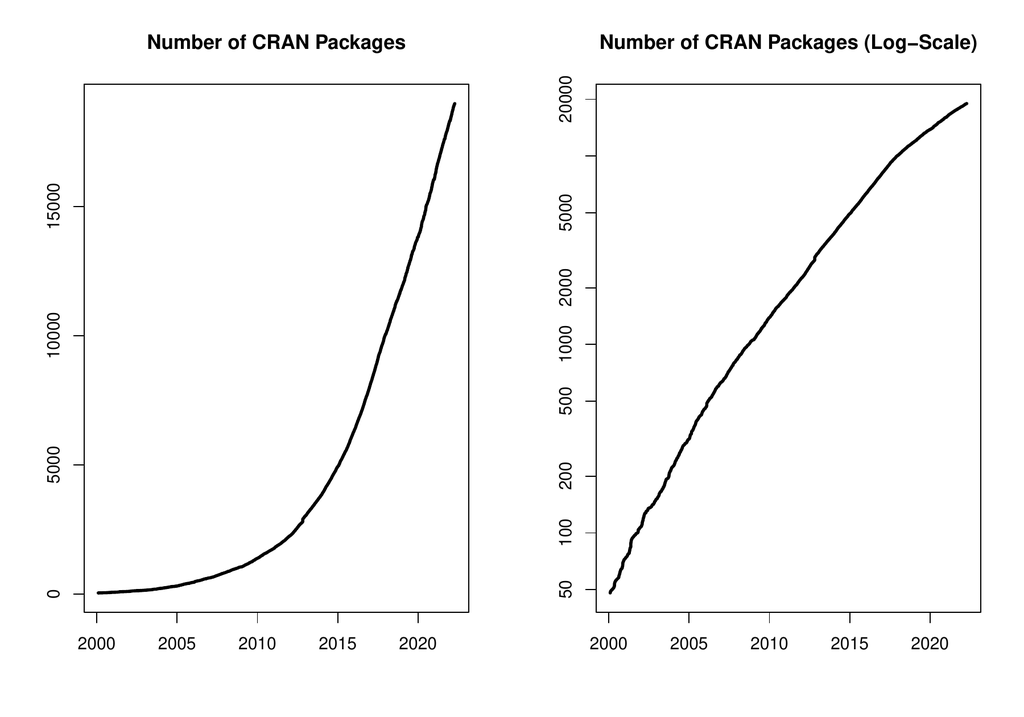

On 2022-03-31, the number of active packages was around 18924.

## Changes in the CRAN Repository Policy

The [Policy](https://CRAN.R-project.org/web/packages/policies.html) now says the following:

- (**Using external C/C++/Fortran libraries.**) Where a package wishes to make use of a library not written solely for the package, the package installation should first look to see if it is already installed and if so is of a suitable version. In case not, it is desirable to include the library sources in the package and compile them as part of package installation. If the sources are too large, it is acceptable to download them as part of installation, but do ensure that the download is of a fixed version rather than the latest. Only as a last resort and with the agreement of the CRAN team should a package download pre-compiled software. On Windows and macOS static libraries must be used. A separate document, [External Libraries for CRAN packages](https://CRAN.R-project.org/web/packages/external_libs.html), covers what external libraries are or could be made available.

## CRAN package submissions

During the first 4 months of 2022 (January 2022 to April 2022), CRAN received 9601 package submissions. For these, 17170 actions took place of which 11232 (65%) were auto processed actions and 5938 (35%) manual actions.

Minus some special cases, a summary of the auto-processed and manually triggered actions follows:

|  | archive | inspect | newbies | pending | pretest | publish | recheck | waiting |
| --- | --- | --- | --- | --- | --- | --- | --- | --- |
| auto | 2391 | 2716 | 1392 | 0 | 0 | 3018 | 1017 | 698 |
| manual | 1893 | 93 | 487 | 323 | 106 | 2232 | 637 | 167 |

These include the final decisions for the submissions which were

| action | archive | publish |
| --- | --- | --- |
| auto | 2232 (23.9%) | 2479 (26.5%) |
| manual | 1870 (20.0%) | 2758 (29.5%) |

where we only count those as *auto* processed whose publication or rejection happened automatically in all steps.

A new team member, Viktoria Wimmer, joined the CRAN submission team. Welcome, Viktoria. Unfortunately, Julia Haider left the CRAN submission team after processing 3517 incoming submissions. Thanks a lot!

## CRAN mirror security

Currently, there are 102 official CRAN mirrors, 81 of which provide both secure downloads via `https` *and* use secure mirroring from the CRAN master (via rsync through ssh tunnels). Since the R 3.4.0 release, `chooseCRANmirror()` offers these mirrors in preference to the others which are not fully secured (yet).

## CRAN Task View Initiative

The transition of the established task views to the new workflow on GitHub (https://github.com/cran-task-views/ctv/) that was announced in the previous volume of the journal has been completed (see also https://twitter.com/AchimZeileis/status/1510945091980038145).

Each task view now links to a GitHub repository where it is possible to post issues and make pull requests for proposing improvements – in addition to sending e-mails to the maintainer address which is still possible, of course. Moreover, the task view web pages contain further improvements like a citation, installation notes, and a streamlined overview of core and regular (and currently archived) packages in the task view.

Proposals of new task views are now also possible on GitHub. In fact, a few have already been made for the topics causal inference, genetics and genomics (as a follow-up to the orphaned and archived *Genetics* and *Phylogenetics* views), and sports analytics.

We look forward to further user contributions to the initiative!